# BasicNNGloveTextClassification_SolutionCopy

## AASD 4011: Applied Mathematical Concepts for Deep Learning

## Final Project: "Benchmarking Sentiment Analysis Neural Networks Models"

### Students:

- Jose Lira (101426814)
- Tuo Xin (101409861)

### Problem Definition

Baseline Our Project takes as a baseline a Notebook from the Deep Learning 1 class in which a Fully connected Neural Network is used for a Movie Sentiment Analysis and a base LSTM Neural Network is also included to solve the same problem.

### Our Analysis

We analyze the effect of changing different parameters in the LSTM and Dense Neural Networks, and include an additional GRU model to benchmark all of them. The initial parameters to be changed and benchmarked would be the following (but more may be included if our analysis finds interesting results during the experimentation):

- ```
   Number of Dense Layers
  ```

- ```
   Number of LSTM layers
  ```

- ```
   Test a GAted REcurrent Unit (GRU) model with simialr featureas than LSTM
  ```

- ```
   Benchmark different number of epochs (increase if the model does not overfit)
  ```

- ```
   Include the Dropout hyperparameter in the LSTM layers
  ```

- ```
   Add Droput Layers in the fully Dense Models
  ```

- ```
   Increase the amount of neurons in the final Dense layers.
  ```

- ```
   Test different activation function
  ```

### Environment

- CPU: 06 Cores Intel Core i7-10750H CPU @ 2.50GHz
- GPU: NVIDIA GeForce RTX2060
- Windows 11
- Pyhton 3.10.9
- TensorFlow 2.10.1

### Preprocessing

- Data Exploration
- Removing Tags, punctuation, and spaces
- Tokenization
- GloVe Embeddings

### Sumary of Models Run

[figure not shown]

### Best Model

Dense Neural Network with 04 Dense Layers and four dropout layers (Model 02)

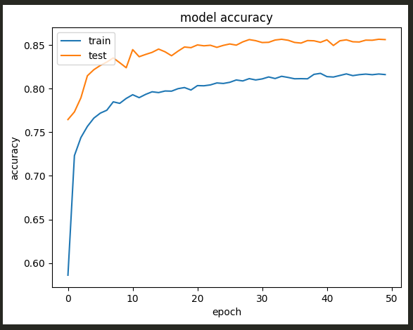

### Model 03: Pure Dense Layers without Dropout

The same dense model has been used without the dropout layers. The result was unsuccessful (we obtained a testing accuracy of 82.44%) as the model with dropout layers was superior.

### Model 04: Adding two addiitonal layers to the Dense Layer model (without Dropout)

In this opportunity, we add two Dense Layers to the model without Dropout layers. The resultant accuracy was 71.21%, which is pretty bad and comparable with the naive baseline model.

### Model 05: GRU

We build a Gated Recurrent Unit (GRU) model to compete with the LSTM and Dense models. The GRU beat the LSTM but could not outperform the Dense Layer model.

### Model 06: LSTM

This was the best of the LSTM models, with a testing accuracy of 84% and a training time of 37min. I did not use any regularization or any dropout hyperparameter. It could not beat the GRU or the dense neural network models.

### Model 07: LSTM

We trained the model for more epochs (150 instead of 100) to improve its performance, as it was still not overfitting. However, we did not improve the original LSTM models with 100 epochs.

### Model 09 LSTM

This is our more complex model with 200 epochs. It took 1 hour and 13 minutes to finish with the GPU, but unfortunately, it did not show any improvement in training or testing accuracy compared to the one with 150 epochs.

### Conclusions

- Beating a vanilla neural network was not easy for much more advanced models. Even though the baseline was beaten by all of them, the second simplest model, another vanilla Neural Network, was unbeatable.
- Training and benchmarking LSTM and GRU can be time-consuming and GPU-intensive (a GPU was mandatory to perform this analysis). When running the models in a CPU, the training time for the LSTM models was more than 8 hours for the simplest one.
- In this sentiment analysis case, the Gated Recurrent Unit (GRU) was more effective than the Long Short Term Memory (LSTM) models in terms of accuracy with similar training time.
- Dropout Layers considerable improved the model tesing accuracy in case of the dense models. This model outperformed all of the LSTM and GRU more complex ones.
- More hyperparameter tuning needs to be done inorder to properly take advantage of the GRU and LSTM models.
- Testing with other advanced configurations using transformers needs to be done to achieve even better resutls than with the Dense neural network.
- Additional testing could be done increaing the Embedding size and the vocabulary size during the prepprocessing.

### Below the details of our work...

### Importing the necessary libraries

```python
import pandas as pd
import numpy as np
import re
import string
import nltk
from nltk.corpus import stopwords
```

```python
from numpy import array
from keras.preprocessing.text import one_hot
#from keras.preprocessing.sequence import pad_sequences
from tensorflow.keras.preprocessing.sequence import pad_sequences
from keras.models import Sequential
from keras.layers import Dense, Flatten
from tensorflow.python.keras.layers.embeddings import Embedding
from sklearn.model_selection import train_test_split
from keras.preprocessing.text import Tokenizer
```

```python
import tensorflow as tf
print(tf.__version__)
print(tf.config.list_physical_devices('GPU'))
```

```
2.10.1
[PhysicalDevice(name='/physical_device:GPU:0', device_type='GPU')]
```

```python
gpu_available = tf.test.is_gpu_available()
is_cuda_gpu_available = tf.test.is_gpu_available(cuda_only=True)
is_cuda_gpu_min_3 = tf.test.is_gpu_available(True, (3,0))
```

```
WARNING:tensorflow:From C:\Users\jlira\AppData\Local\Temp\ipykernel_6880\670937279.py:1: is_gpu_available (from tensorflow.python.framework.test_util) is deprecated and will be removed in a future version.
Instructions for updating:
Use `tf.config.list_physical_devices('GPU')` instead.
```

```python
print(gpu_available)
print(is_cuda_gpu_available)
print(is_cuda_gpu_min_3)
```

```
True
True
True
```

### Download the dataset from Kaggle

https://www.kaggle.com/lakshmi25npathi/imdb-dataset-of-50k-movie-reviews

### Data Exploration

```python
movie_reviews = pd.read_csv('IMDB Dataset.csv')
movie_reviews.head()
```

|  | review | sentiment |
| --- | --- | --- |
| 0 | One of the other reviewers has mentioned that ... | positive |
| 1 | A wonderful little production. <br /><br />The... | positive |
| 2 | I thought this was a wonderful way to spend ti... | positive |
| 3 | Basically there's a family where a little boy ... | negative |
| 4 | Petter Mattei's "Love in the Time of Money" is... | positive |

```python
movie_reviews.isnull().values.any()
```

```
False
```

```python
movie_reviews.shape
```

```
(50000, 2)
```

```python
movie_reviews["review"][3]
```

```
"Basically there's a family where a little boy (Jake) thinks there's a zombie in his closet & his parents are fighting all the time.<br /><br />This movie is slower than a soap opera... and suddenly, Jake decides to become Rambo and kill the zombie.<br /><br />OK, first of all when you're going to m…
```

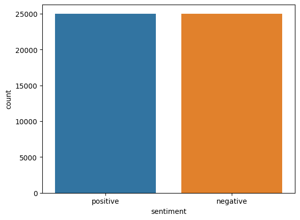

```python
import seaborn as sns
import matplotlib.pyplot as plt
%matplotlib inline
sns.countplot(x='sentiment', data=movie_reviews)
```

### Pre-processing of text

- Removing html tags
- Removing punctutations and numbers
- Removing Multiple spaces
- so on

```python
stop_words = stopwords.words('english') #English language's stop words

def textpreprocess(s):
    """This function cleans the text
    Input: string to be cleaned
    Return: string after cleaning
    """
    words = [] # empty list

    s = s.strip().lower() # lower the string
    s = re.sub('\[.*?\]', '', s) # removes symbols (.*?\)
    s = re.sub('https?://\S+|www\.\S+', '', s) # remove URLS
    s = re.sub('<.*?>+', '', s)
    s = re.sub('[%s]' % re.escape(string.punctuation), '', s) # remove punctuations
    s = re.sub('\n', '', s) # remove next line character
    s = re.sub('\w*\d\w*', '', s)

    words = s.split() # split the string into list of words
    words = [word for word in words if word not in stop_words] # removing stop words
    s = ' '.join(words) # converting list to string

    return s
```

```python
%%time
X = []
sentences = list(movie_reviews['review'])
for sen in sentences:
    X.append(textpreprocess(sen))
```

```
CPU times: total: 18.5 s
Wall time: 18.5 s
```

```python
X[3]
```

```
'basically theres family little boy jake thinks theres zombie closet parents fighting timethis movie slower soap opera suddenly jake decides become rambo kill zombieok first youre going make film must decide thriller drama drama movie watchable parents divorcing arguing like real life jake closet to…
```

### Creating numerical labels from categorical values

```python
y = movie_reviews['sentiment']

y = np.array(list(map(lambda x: 1 if x=="positive" else 0, y)))
```

### Split the dataset to train and test

```python
X_train, X_test, y_train, y_test = train_test_split(X, y, test_size=0.20, random_state=42)
```

```python
len(X_train)
```

```
40000
```

```python
# X_train
```

### Use Tokenizer to integer encode the documents

```python
# hyperparameters
num_words_ = 5000
oov_tok = "<OOV>"

tokenizer = Tokenizer(num_words=num_words_, oov_token=oov_tok)
tokenizer.fit_on_texts(X_train)

X_train = tokenizer.texts_to_sequences(X_train)
X_test = tokenizer.texts_to_sequences(X_test)
```

```python
# X_train[0]
```

[output not shown]

[output cut: 153 more lines]

[output not shown]

```python
tokenizer.word_index
```

[output not shown]

[output cut: 946 more lines]

[output not shown]

### Pad Sequences to create equal-length inputs

```python
vocab_size = len(tokenizer.word_index) + 1

maxlen = 500
trunc_type='post'
padding_type='post'

X_train = pad_sequences(X_train, maxlen=maxlen, truncating= trunc_type, padding=padding_type)
X_test = pad_sequences(X_test, padding=padding_type, maxlen=maxlen, truncating= trunc_type)
```

### Load GloVe embedding into memory

### GloVe Embeddings

- glove.6B.50d.txt (` 175 MB)

https://www.kaggle.com/datasets/watts2/glove6b50dtxt

```python
from numpy import array
from numpy import asarray
from numpy import zeros

embeddings_dictionary = dict()
glove_file = open('glove.6B.50d.txt', encoding="utf8")

for line in glove_file:
    records = line.split()
    word = records[0]
    vector_dimensions = asarray(records[1:], dtype='float32')
    embeddings_dictionary [word] = vector_dimensions
glove_file.close()
```

```python
# embeddings_dictionary
```

### Create Embedding matrix for our Kaggle dataset

```python
embedding_matrix = zeros((vocab_size, 50))
for word, index in tokenizer.word_index.items():
    embedding_vector = embeddings_dictionary.get(word)
    if embedding_vector is not None:
        embedding_matrix[index] = embedding_vector
```

### Model 01: Build the Baseline Model - Basic Neural Network

```python
model = Sequential()
embedding_layer = Embedding(vocab_size,
                            50,
                            weights=[embedding_matrix],
                            input_length=maxlen ,
                            trainable=False)
model.add(embedding_layer)
model.add(Flatten())
model.add(Dense(1, activation='sigmoid'))
```

### Compile the model

```python
model.compile(optimizer='adam',
              loss='binary_crossentropy',
              metrics=['acc'])
# print(model.summary())
```

### Fit the model

```python
%%time
history = model.fit(X_train,
                    y_train,
                    batch_size=128,
                    epochs=50,
                    verbose=1,
                    validation_split=0.2)
```

```
CPU times: total: 40.9 s
Wall time: 30.3 s
```

```python
print(model.summary())
```

```
Model: "sequential"
_________________________________________________________________
 Layer (type)                Output Shape              Param #
=================================================================
 module_wrapper (ModuleWrapp  (None, 500, 50)          9309450
 er)

 flatten (Flatten)           (None, 25000)             0

 dense (Dense)               (None, 1)                 25001

=================================================================
Total params: 9,334,451
Trainable params: 25,001
Non-trainable params: 9,309,450
_________________________________________________________________
None
```

### Evaluate Training phase

```python
score = model.evaluate(X_train, y_train, verbose=1)
score
```

```
[0.4505900740623474, 0.8376500010490417]
```

```python
print("Train Loss:", score[0])
print("Train Accuracy:", score[1])
```

```
Train Loss: 0.4505900740623474
Train Accuracy: 0.8376500010490417
```

### Evaluate Testing phase

```python
score = model.evaluate(X_test, y_test, verbose=1)
score
```

```
[1.1329256296157837, 0.6991999745368958]
```

```python
print("Test Loss:", score[0])
print("Test Accuracy:", score[1])
```

```
Test Loss: 1.1329256296157837
Test Accuracy: 0.6991999745368958
```

### Plot the training and testing accuracy and loss

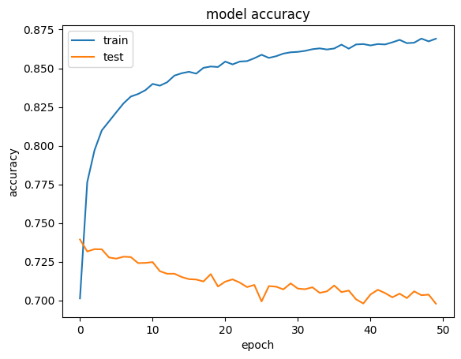

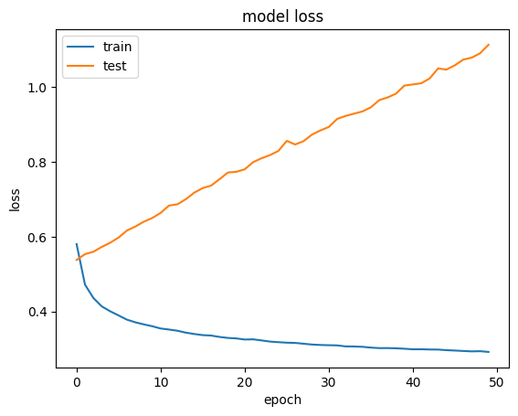

```python
import matplotlib.pyplot as plt

plt.plot(history.history['acc'])
plt.plot(history.history['val_acc'])

plt.title('model accuracy')
plt.ylabel('accuracy')
plt.xlabel('epoch')
plt.legend(['train','test'], loc='upper left')
plt.show()

plt.plot(history.history['loss'])
plt.plot(history.history['val_loss'])

plt.title('model loss')
plt.ylabel('loss')
plt.xlabel('epoch')
plt.legend(['train','test'], loc='upper left')
plt.show()
```

high variance

```python
from tensorflow.keras.layers import Dropout
```

```python
model = Sequential()
embedding_layer = Embedding(vocab_size,
                            50,
                            weights=[embedding_matrix],
                            input_length=maxlen ,
                            trainable=False)
model.add(embedding_layer)
model.add(Dropout(0.5))
model.add(Dense(256, activation='relu'))
model.add(Dropout(0.5))
model.add(Dense(128, activation='relu'))
model.add(Dropout(0.5))
model.add(Dense(64, activation='relu'))
model.add(Dropout(0.5))
model.add(Flatten())
model.add(Dense(1, activation='sigmoid'))

model.compile(optimizer='adam', loss='binary_crossentropy', metrics=['acc'])

# print(model.summary())
```

```python
%%time
history = model.fit(X_train, y_train, batch_size=128, epochs=50, verbose=1, validation_split=0.2)
```

```
CPU times: total: 4min 17s
Wall time: 4min 1s
```

```python
print(model.summary())
```

```
Model: "sequential_1"
_________________________________________________________________
 Layer (type)                Output Shape              Param #
=================================================================
 module_wrapper_1 (ModuleWra  (None, 500, 50)          9309450
 pper)

 dropout (Dropout)           (None, 500, 50)           0

 dense_1 (Dense)             (None, 500, 256)          13056

 dropout_1 (Dropout)         (None, 500, 256)          0

 dense_2 (Dense)             (None, 500, 128)          32896

 dropout_2 (Dropout)         (None, 500, 128)          0

 dense_3 (Dense)             (None, 500, 64)           8256

 dropout_3 (Dropout)         (None, 500, 64)           0

 flatten_1 (Flatten)         (None, 32000)             0

 dense_4 (Dense)             (None, 1)                 32001

=================================================================
Total params: 9,395,659
Trainable params: 86,209
Non-trainable params: 9,309,450
_________________________________________________________________
None
```

### Evaluate Training phase

```python
score = model.evaluate(X_train, y_train, verbose=1)
score
```

```
[0.3200356364250183, 0.8727750182151794]
```

```python
print("Train Loss:", score[0])
print("Train Accuracy:", score[1])
```

```
Train Loss: 0.3200356364250183
Train Accuracy: 0.8727750182151794
```

### Evaluate Testing phase

```python
score = model.evaluate(X_test, y_test, verbose=1)
score
```

```
[0.3504055142402649, 0.8536999821662903]
```

```python
print("Test Loss:", score[0])
print("Test Accuracy:", score[1])
```

```
Test Loss: 0.3504055142402649
Test Accuracy: 0.8536999821662903
```

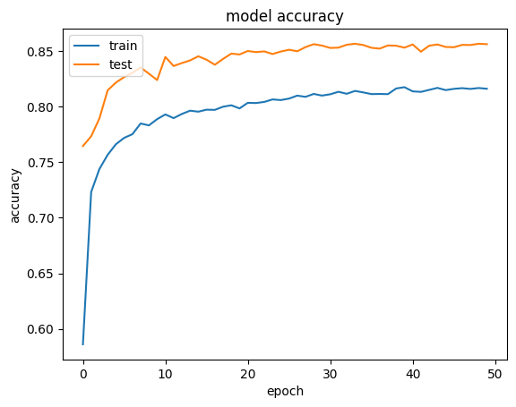

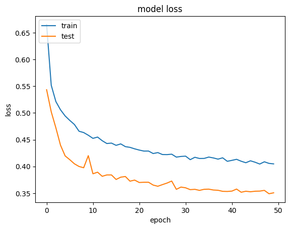

```python
import matplotlib.pyplot as plt

plt.plot(history.history['acc'])
plt.plot(history.history['val_acc'])

plt.title('model accuracy')
plt.ylabel('accuracy')
plt.xlabel('epoch')
plt.legend(['train','test'], loc='upper left')
plt.show()

plt.plot(history.history['loss'])
plt.plot(history.history['val_loss'])

plt.title('model loss')
plt.ylabel('loss')
plt.xlabel('epoch')
plt.legend(['train','test'], loc='upper left')
plt.show()
```

### Model 03: Four Dense Layers without dropout

```python
model = Sequential()
embedding_layer = Embedding(vocab_size, 50, weights=[embedding_matrix], input_length=maxlen , trainable=False)
model.add(embedding_layer)
model.add(Dense(256, activation='relu'))
model.add(Dense(128, activation='relu'))
model.add(Dense(64, activation='relu'))
model.add(Flatten())
model.add(Dense(1, activation='sigmoid'))

model.compile(optimizer='adam', loss='binary_crossentropy', metrics=['acc'])
```

### Compile the model

```python
model.compile(optimizer='adam',
              loss='binary_crossentropy',
              metrics=['acc']
             )

# print(model.summary())
```

### Fit the model

```python
%%time
history = model.fit(X_train,
                    y_train,
                    batch_size=32,
                    epochs=30,
                    verbose=1,
                    validation_data=(X_test, y_test))
```

```
CPU times: total: 3min 25s
Wall time: 2min 52s
```

```python
print(model.summary())
```

```
Model: "sequential_2"
_________________________________________________________________
 Layer (type)                Output Shape              Param #
=================================================================
 module_wrapper_2 (ModuleWra  (None, 500, 50)          9309450
 pper)

 dense_5 (Dense)             (None, 500, 256)          13056

 dense_6 (Dense)             (None, 500, 128)          32896

 dense_7 (Dense)             (None, 500, 64)           8256

 flatten_2 (Flatten)         (None, 32000)             0

 dense_8 (Dense)             (None, 1)                 32001

=================================================================
Total params: 9,395,659
Trainable params: 86,209
Non-trainable params: 9,309,450
_________________________________________________________________
None
```

### Evaluate Training phase

```python
score = model.evaluate(X_train, y_train, verbose=1)
score
```

```
[0.031558260321617126, 0.9890750050544739]
```

```python
print("Train Loss:", score[0])
print("Train Accuracy:", score[1])
```

```
Train Loss: 0.031558260321617126
Train Accuracy: 0.9890750050544739
```

### Evaluate Testing phase

```python
score = model.evaluate(X_test, y_test, verbose=1)
score
```

```
[1.6920628547668457, 0.824400007724762]
```

```python
print("Test Loss:", score[0])
print("Test Accuracy:", score[1])
```

```
Test Loss: 1.6920628547668457
Test Accuracy: 0.824400007724762
```

### Plot the training and testing accuracy and loss

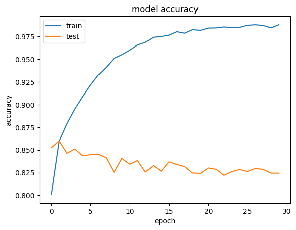

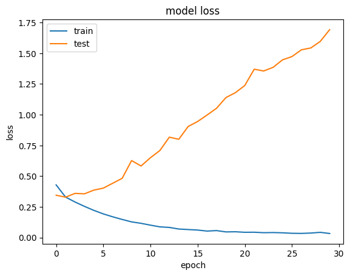

```python
import matplotlib.pyplot as plt

plt.plot(history.history['acc'])
plt.plot(history.history['val_acc'])

plt.title('model accuracy')
plt.ylabel('accuracy')
plt.xlabel('epoch')
plt.legend(['train','test'], loc='upper left')
plt.show()

plt.plot(history.history['loss'])
plt.plot(history.history['val_loss'])

plt.title('model loss')
plt.ylabel('loss')
plt.xlabel('epoch')
plt.legend(['train','test'], loc='upper left')
plt.show()
```

### Model 04: Dense Neural Network with more layers

```python
model = Sequential()
embedding_layer = Embedding(vocab_size,
                            50,
                            weights=[embedding_matrix],
                            input_length=maxlen ,
                            trainable=False)
model.add(embedding_layer)
model.add(Flatten())
model.add(Dense(128, activation='relu'))
model.add(Dense(64, activation='relu'))
model.add(Dense(32, activation='relu'))
model.add(Dense(16, activation='relu'))
model.add(Dense(8, activation='relu'))
model.add(Dense(1, activation='sigmoid'))
```

### Compile the model

```python
model.compile(optimizer=tf.keras.optimizers.Adam(learning_rate=0.00001),
              loss='binary_crossentropy',
              metrics=['acc']
             )

# print(model.summary())
```

### Fit the model

```python
%%time
history = model.fit(X_train,
                    y_train,
                    batch_size=32,
                    epochs=30,
                    verbose=1,
                    validation_data=(X_test, y_test))
```

```
CPU times: total: 2min 41s
Wall time: 2min 17s
```

```python
print(model.summary())
```

```
Model: "sequential_3"
_________________________________________________________________
 Layer (type)                Output Shape              Param #
=================================================================
 module_wrapper_3 (ModuleWra  (None, 500, 50)          9309450
 pper)

 flatten_3 (Flatten)         (None, 25000)             0

 dense_9 (Dense)             (None, 128)               3200128

 dense_10 (Dense)            (None, 64)                8256

 dense_11 (Dense)            (None, 32)                2080

 dense_12 (Dense)            (None, 16)                528

 dense_13 (Dense)            (None, 8)                 136

 dense_14 (Dense)            (None, 1)                 9

=================================================================
Total params: 12,520,587
Trainable params: 3,211,137
Non-trainable params: 9,309,450
_________________________________________________________________
None
```

### Evaluate Training phase

```python
score = model.evaluate(X_train, y_train, verbose=1)
score
```

```
[0.0015003059525042772, 0.999875009059906]
```

```python
print("Train Loss:", score[0])
print("Train Accuracy:", score[1])
```

```
Train Loss: 0.0015003059525042772
Train Accuracy: 0.999875009059906
```

### Evaluate Testing phase

```python
score = model.evaluate(X_test, y_test, verbose=1)
score
```

```
[2.22851300239563, 0.7121999859809875]
```

```python
print("Test Loss:", score[0])
print("Test Accuracy:", score[1])
```

```
Test Loss: 2.22851300239563
Test Accuracy: 0.7121999859809875
```

### Plot the training and testing accuracy and loss

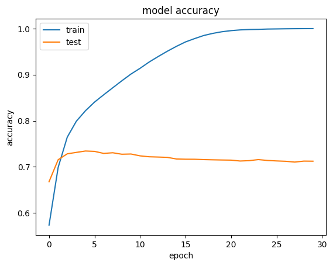

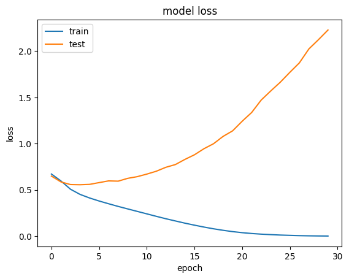

```python
import matplotlib.pyplot as plt

plt.plot(history.history['acc'])
plt.plot(history.history['val_acc'])

plt.title('model accuracy')
plt.ylabel('accuracy')
plt.xlabel('epoch')
plt.legend(['train','test'], loc='upper left')
plt.show()

plt.plot(history.history['loss'])
plt.plot(history.history['val_loss'])

plt.title('model loss')
plt.ylabel('loss')
plt.xlabel('epoch')
plt.legend(['train','test'], loc='upper left')
plt.show()
```

### Model 05: Build a GRU model

```python
from tensorflow.keras.layers import GRU
```

```python
model = Sequential()
embedding_layer = Embedding(vocab_size, 50, weights=[embedding_matrix], input_length=maxlen , trainable=False)
model.add(embedding_layer)
model.add(GRU(32,  return_sequences=True))
model.add(GRU(32))
model.add(Dense(16, activation='relu'))
model.add(Dense(1, activation='sigmoid'))
```

```python
model.compile(optimizer='adam', loss='binary_crossentropy', metrics=['accuracy'])
```

```python
%%time
history = model.fit(X_train, y_train, batch_size=128, epochs=100, verbose=1, validation_data=(X_test, y_test))
```

```
CPU times: total: 37min 33s
Wall time: 38min 34s
```

### Evaluate Training phase

```python
score = model.evaluate(X_train, y_train, verbose=1)
score
```

```
[0.12995971739292145, 0.9565500020980835]
```

```python
print("Train Loss:", score[0])
print("Train Accuracy:", score[1])
```

```
Train Loss: 0.12995971739292145
Train Accuracy: 0.9565500020980835
```

### Evaluate Testing phase

```python
score = model.evaluate(X_test, y_test, verbose=1)
```

```python
print("Test Loss:", score[0])
print("Test Accuracy:", score[1])
```

```
Test Loss: 0.49510931968688965
Test Accuracy: 0.8450999855995178
```

### Plot the training and testing accuracy and loss

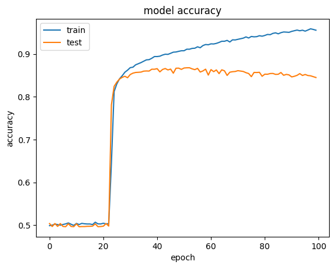

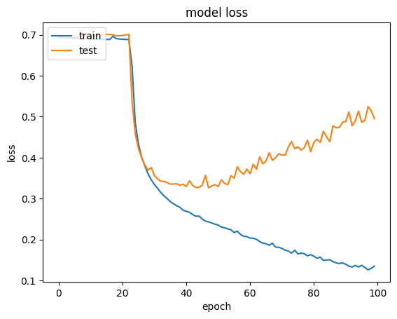

```python
import matplotlib.pyplot as plt

plt.plot(history.history['accuracy'])
plt.plot(history.history['val_accuracy'])

plt.title('model accuracy')
plt.ylabel('accuracy')
plt.xlabel('epoch')
plt.legend(['train','test'], loc='upper left')
plt.show()

plt.plot(history.history['loss'])
plt.plot(history.history['val_loss'])

plt.title('model loss')
plt.ylabel('loss')
plt.xlabel('epoch')
plt.legend(['train','test'], loc='upper left')
plt.show()
```

```python
from tensorflow.keras.layers import LSTM
```

### Model 06: Long Short Term Memory (LSTM) Neural Network

```python
model = Sequential()
embedding_layer = Embedding(vocab_size, 50, weights=[embedding_matrix], input_length=maxlen , trainable=False)
model.add(embedding_layer)
model.add(LSTM(32, activation='tanh', return_sequences=True))
model.add(LSTM(32, activation='tanh'))
model.add(Dense(16, activation='sigmoid'))
model.add(Dense(1, activation='sigmoid'))
```

### Compile the model

```python
model.compile(optimizer='rmsprop', loss='binary_crossentropy', metrics=['accuracy'])
```

### Fit the model

```python
%%time
history = model.fit(X_train, y_train, batch_size=128, epochs=100, verbose=1, validation_data=(X_test, y_test))
```

```
CPU times: total: 35min 45s
Wall time: 36min 37s
```

```python
print(model.summary())
```

```
Model: "sequential_15"
_________________________________________________________________
 Layer (type)                Output Shape              Param #
=================================================================
 module_wrapper_15 (ModuleWr  (None, 500, 50)          9309450
 apper)

 lstm_8 (LSTM)               (None, 500, 32)           10624

 lstm_9 (LSTM)               (None, 32)                8320

 dense_28 (Dense)            (None, 16)                528

 dense_29 (Dense)            (None, 1)                 17

=================================================================
Total params: 9,328,939
Trainable params: 19,489
Non-trainable params: 9,309,450
_________________________________________________________________
None
```

### Evaluate Training phase

```python
score = model.evaluate(X_train, y_train, verbose=1)
score
```

```
[0.3628646731376648, 0.8462749719619751]
```

```python
print("Train Loss:", score[0])
print("Train Accuracy:", score[1])
```

```
Train Loss: 0.3628646731376648
Train Accuracy: 0.8462749719619751
```

### Evaluate Testing phase

```python
score = model.evaluate(X_test, y_test, verbose=1)
```

```python
print("Test Loss:", score[0])
print("Test Accuracy:", score[1])
```

```
Test Loss: 0.3801719546318054
Test Accuracy: 0.839900016784668
```

### Plot the training and testing accuracy and loss

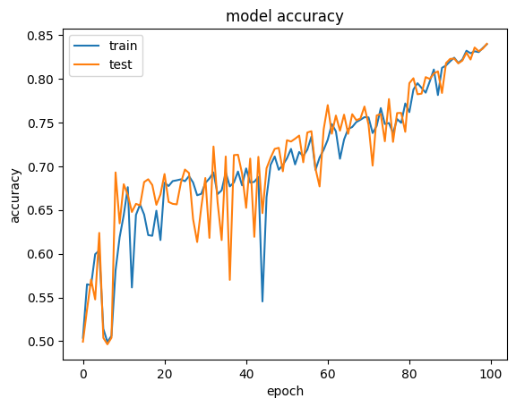

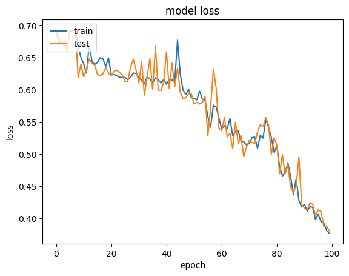

```python
import matplotlib.pyplot as plt

plt.plot(history.history['accuracy'])
plt.plot(history.history['val_accuracy'])

plt.title('model accuracy')
plt.ylabel('accuracy')
plt.xlabel('epoch')
plt.legend(['train','test'], loc='upper left')
plt.show()

plt.plot(history.history['loss'])
plt.plot(history.history['val_loss'])

plt.title('model loss')
plt.ylabel('loss')
plt.xlabel('epoch')
plt.legend(['train','test'], loc='upper left')
plt.show()
```

### Model 07: Long Short Term Memory Neural Network with more epochs

```python
model = Sequential()
embedding_layer = Embedding(vocab_size, 50, weights=[embedding_matrix], input_length=maxlen , trainable=False)
model.add(embedding_layer)
model.add(LSTM(32, activation='tanh', return_sequences=True))
model.add(LSTM(32, activation='tanh'))
model.add(Dense(16, activation='sigmoid'))
model.add(Dense(1, activation='sigmoid'))
```

### Compile the model

```python
model.compile(optimizer='rmsprop', loss='binary_crossentropy', metrics=['accuracy'])
```

### Fit the Model

```python
%%time
history = model.fit(X_train,
                    y_train,
                    batch_size=128,
                    epochs=150,
                    verbose=1,
                    validation_data=(X_test, y_test))
```

```
CPU times: total: 53min 30s
Wall time: 54min 54s
```

```python
print(model.summary())
```

```
Model: "sequential_16"
_________________________________________________________________
 Layer (type)                Output Shape              Param #
=================================================================
 module_wrapper_16 (ModuleWr  (None, 500, 50)          9309450
 apper)

 lstm_10 (LSTM)              (None, 500, 32)           10624

 lstm_11 (LSTM)              (None, 32)                8320

 dense_30 (Dense)            (None, 16)                528

 dense_31 (Dense)            (None, 1)                 17

=================================================================
Total params: 9,328,939
Trainable params: 19,489
Non-trainable params: 9,309,450
_________________________________________________________________
None
```

### Evaluate Training phase

```python
score = model.evaluate(X_train, y_train, verbose=1)
score
```

```
[0.27569273114204407, 0.8687750101089478]
```

```python
print("Train Loss:", score[0])
print("Train Accuracy:", score[1])
```

```
Train Loss: 0.27569273114204407
Train Accuracy: 0.8687750101089478
```

### Evaluate Testing phase

```python
score = model.evaluate(X_test, y_test, verbose=1)
```

```python
print("Test Loss:", score[0])
print("Test Accuracy:", score[1])
```

```
Test Loss: 0.4021351635456085
Test Accuracy: 0.8205000162124634
```

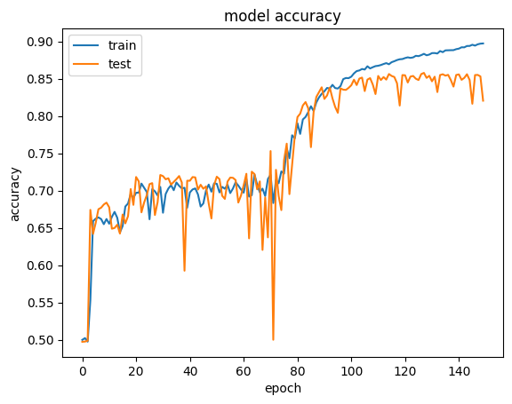

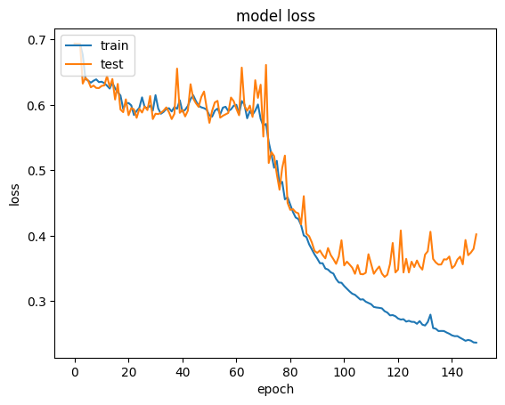

```python
import matplotlib.pyplot as plt

plt.plot(history.history['accuracy'])
plt.plot(history.history['val_accuracy'])

plt.title('model accuracy')
plt.ylabel('accuracy')
plt.xlabel('epoch')
plt.legend(['train','test'], loc='upper left')
plt.show()

plt.plot(history.history['loss'])
plt.plot(history.history['val_loss'])

plt.title('model loss')
plt.ylabel('loss')
plt.xlabel('epoch')
plt.legend(['train','test'], loc='upper left')
plt.show()
```

### Model 08: Long Short Term Memory Neural Network with Dropout in the two LSTM layers

```python
model = Sequential()
embedding_layer = Embedding(vocab_size,
                            50,
                            weights=[embedding_matrix],
                            input_length=maxlen ,
                            trainable=False)
model.add(embedding_layer)
model.add(LSTM(32,
               activation='tanh',
               return_sequences=True,
               dropout=0.8))
model.add(LSTM(32,
               activation='tanh',
               dropout=0.8))
model.add(Dense(16, activation='sigmoid'))
model.add(Dense(1, activation='sigmoid'))
```

```python
model.compile(optimizer='rmsprop', loss='binary_crossentropy', metrics=['accuracy'])
```

```python
%%time
history = model.fit(X_train,
                    y_train,
                    batch_size=128,
                    epochs=150,
                    verbose=1,
                    validation_data=(X_test, y_test))
```

```
CPU times: total: 53min 56s
Wall time: 54min 35s
```

```python
print(model.summary())
```

```
Model: "sequential_17"
_________________________________________________________________
 Layer (type)                Output Shape              Param #
=================================================================
 module_wrapper_17 (ModuleWr  (None, 500, 50)          9309450
 apper)

 lstm_12 (LSTM)              (None, 500, 32)           10624

 lstm_13 (LSTM)              (None, 32)                8320

 dense_32 (Dense)            (None, 16)                528

 dense_33 (Dense)            (None, 1)                 17

=================================================================
Total params: 9,328,939
Trainable params: 19,489
Non-trainable params: 9,309,450
_________________________________________________________________
None
```

### Evaluate Training phase

```python
score = model.evaluate(X_train, y_train, verbose=1)
score
```

```
[0.4118306040763855, 0.8159999847412109]
```

```python
print("Train Loss:", score[0])
print("Train Accuracy:", score[1])
```

```
Train Loss: 0.4118306040763855
Train Accuracy: 0.8159999847412109
```

### Evaluate Testing phase

```python
score = model.evaluate(X_test, y_test, verbose=1)
```

```python
print("Test Loss:", score[0])
print("Test Accuracy:", score[1])
```

```
Test Loss: 0.4158443212509155
Test Accuracy: 0.8130000233650208
```

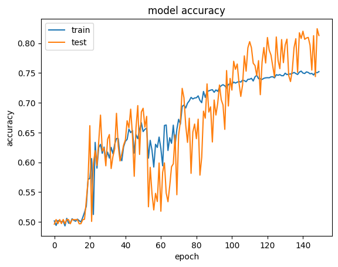

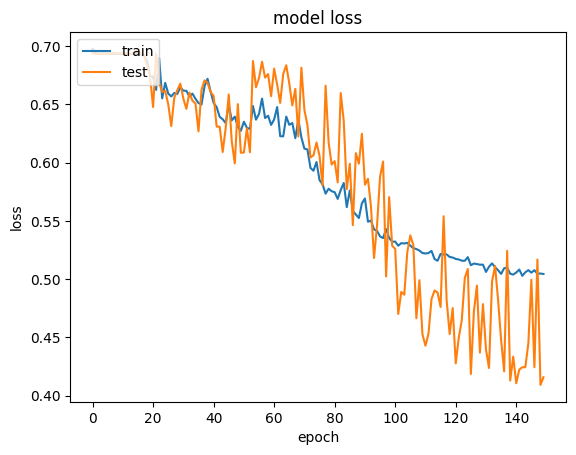

```python
import matplotlib.pyplot as plt

plt.plot(history.history['accuracy'])
plt.plot(history.history['val_accuracy'])

plt.title('model accuracy')
plt.ylabel('accuracy')
plt.xlabel('epoch')
plt.legend(['train','test'], loc='upper left')
plt.show()

plt.plot(history.history['loss'])
plt.plot(history.history['val_loss'])

plt.title('model loss')
plt.ylabel('loss')
plt.xlabel('epoch')
plt.legend(['train','test'], loc='upper left')
plt.show()
```

### Model 09: LSTM Neural Network with dropout in the two LSTM Layers and 200 epochs

```python
model = Sequential()
embedding_layer = Embedding(vocab_size,
                            50,
                            weights=[embedding_matrix],
                            input_length=maxlen ,
                            trainable=False)
model.add(embedding_layer)
model.add(LSTM(32,
               activation='tanh',
               return_sequences=True,
               dropout=0.8))
model.add(LSTM(32,
               activation='tanh',
               dropout=0.8))
model.add(Dense(16, activation='sigmoid'))
model.add(Dense(1, activation='sigmoid'))
```

```python
model.compile(optimizer='rmsprop', loss='binary_crossentropy', metrics=['accuracy'])
```

```python
%%time
history = model.fit(X_train,
                    y_train,
                    batch_size=128,
                    epochs=200,
                    verbose=1,
                    validation_data=(X_test, y_test))
```

```
CPU times: total: 1h 12min 6s
Wall time: 1h 13min 5s
```

```python
print(model.summary())
```

```
Model: "sequential_18"
_________________________________________________________________
 Layer (type)                Output Shape              Param #
=================================================================
 module_wrapper_18 (ModuleWr  (None, 500, 50)          9309450
 apper)

 lstm_14 (LSTM)              (None, 500, 32)           10624

 lstm_15 (LSTM)              (None, 32)                8320

 dense_34 (Dense)            (None, 16)                528

 dense_35 (Dense)            (None, 1)                 17

=================================================================
Total params: 9,328,939
Trainable params: 19,489
Non-trainable params: 9,309,450
_________________________________________________________________
None
```

### Evaluate Training phase

```python
score = model.evaluate(X_train, y_train, verbose=1)
score
```

```
[0.4189704656600952, 0.8155999779701233]
```

```python
print("Train Loss:", score[0])
print("Train Accuracy:", score[1])
```

```
Train Loss: 0.4189704656600952
Train Accuracy: 0.8155999779701233
```

### Evaluate Testing phase

```python
score = model.evaluate(X_test, y_test, verbose=1)
```

```python
print("Test Loss:", score[0])
print("Test Accuracy:", score[1])
```

```
Test Loss: 0.4230899512767792
Test Accuracy: 0.8105999827384949
```

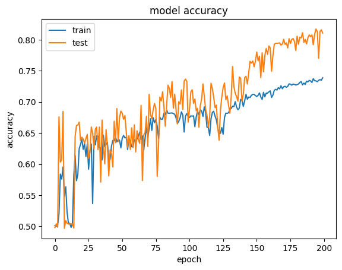

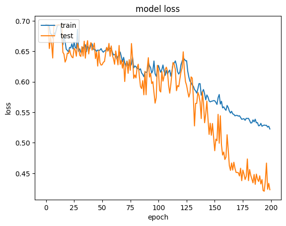

```python
import matplotlib.pyplot as plt

plt.plot(history.history['accuracy'])
plt.plot(history.history['val_accuracy'])

plt.title('model accuracy')
plt.ylabel('accuracy')
plt.xlabel('epoch')
plt.legend(['train','test'], loc='upper left')
plt.show()

plt.plot(history.history['loss'])
plt.plot(history.history['val_loss'])

plt.title('model loss')
plt.ylabel('loss')
plt.xlabel('epoch')
plt.legend(['train','test'], loc='upper left')
plt.show()
```